# **Net-zero multi-energy systems.**

## Indice

- 1. Introducción
- 2. Descripción de la Base de Datos
- 3. Análisis Exploratorio de Datos
  - 3.1. Análisis Multivariado
  - 3.2. Análisis Univariado Según el Tipo de Tecnología
    - 3.2.1. SFV - Solar Fotovoltaica
    - 3.2.2. H - Hidroélectrica
    - 3.2.3. O - Otros
    - 3.2.4. I - Interconexión a otro país
    - 3.2.5. B - Biomasa
- 4. Visualizaciones de Mapa
  - 4.1 General
  - 4.2 Solar Fotovoltaica - SFV
  - 4.3 Hidroélectrica - H
  - 4.4 Otros - O
  - 4.5 Interconexión a otro país - I
  - 4.6 Biomasa - B
- 5. Demanda en el tiempo
  - 5.1 Según los días
  - 5.2 Según los meses
  - 5.3 Según los años
- 6. Conclusiones

## 1. Introducción

La energía es uno de los principales recursos para los seres humanos. Por desgracia las formas de obtención y uso han causado un gran impacto ambiental, generando la necesidad de crear sistemas de energías sostenibles y de cero emisiones. Estos buscan reemplazar los métodos tradicionales, como lo son la solar fotovoltaica, hidráulica, eólica o biomasa. Por sus características, se suelen emplear para cubrir las necesidades energéticas de áreas rurales e independientes, pues son estas áreas las que tienen mayor dificultad para lograr acceder a las fuentes de energía tradicional.

Este documento se enfoca en el análisis de la base de datos [Registros de Operación](https://www.datos.gov.co/Minas-y-Energ-a/Superservicios-Registro-De-Operaci-n-Diario-Otro-T/bsnu-ddmp). Por medio de la identificación de patrones, características y correlaciones según el área o los tipos de tecnología, se busca mejorar la toma de decisiones y la según el tipo de tecnología. Así se logra contribuir a la planeación y creación de sistemas energéticos de cero emisiones, con un modelo efectivo y eficiente, que representa la realidad en las áreas rurales e independientes.

Con el fin de lograr esto, se utilizo la plataforma de Google Colab, la libreria [GeoJSON](https://gist.github.com/john-guerra/43c7656821069d00dcbc) y las siguientes librerias:

```python
import pandas as pd                                         # pip install pandas
import matplotlib                                           # pip install matplotlib
import matplotlib.pyplot as plt
import numpy as np                                          # pip install numpy
from datetime import datetime
import seaborn as sns                                       # pip install seaborn
import os
import json
import plotly.express as px                                 # pip install plotly nbformat
import plotly
from pingouin import multivariate_normality                 # pip install pingouin
from scipy.stats import normaltest                          # pip install scipy
```

```
pip install pandas matplotlib numpy seaborn plotly nbformat pingouin scipy plot_utils -U kaleido
```

## 2. Descripción de la base de datos

En la base de datos [Registros de Operación](https://www.datos.gov.co/Minas-y-Energ-a/Superservicios-Registro-De-Operaci-n-Diario-Otro-T/bsnu-ddmp) se encuentran las siguientes columnas:

- *Código Localidad*: Corresponde a la división político-administrativa de Colombia con la siguiente estructura *DDMMMCCC* + *LLLLL* consecutivo del código asignado SSPD. Donde *DD* es el código del Departamento, *MMM* corresponde al código Municipio, *CCC* corresponde al código del Centro Poblado. Si la localidad no se encuentra en la codificación DANE se registra el campo de la Cabecera Municipal. Además de *LLLLL*, consecutivo asignado por la SSPD.
- *Tipo de Tecnología*: Corresponde a la codificación según el tipo de tecnología utilizada para generar (entregar) energía en la localidad y está dada por la siguiente tabla: *H* Hidroélectrica, *B* Biomasa, *E* Eólica, *TG* Térmica a Gas, *TC* Térmica a Carbón, *TBG* Térmica a Biogás, *I* Interconexión a otro país, *SFV* Solar Fotovoltaica y *O* que corresponde a Otros.
- *Kms de Red Interconexión*: Corresponde a los kilómetros de subtransmisión existentes para interconectar dos mercados ZNI.
- *Capacidad (kW)*: Corresponde a la capacidad existente en la central eléctrica. **En el caso de Interconexiones este campo se debe estar vacío**.
- *Fecha*: Se refiere a la fecha en que fue prestado el servicio y de la cual se están reportando los datos de operación de la central de generación o la interconexión.
- *Horas de Servicio*: Corresponde al número de horas diarias que prestó el servicio en la fecha señalada.
- *Energía Entregada (kWh)*: Corresponde a la lectura real de la Energía generada en el día. Para el caso de una interconexión eléctrica debe ser la energía activa medida cuyo dato es tomado la frontera comercial o en el punto de entrega de energía al Distribuidor comercializador.
- *ID Empresa*, *Nombre*, *Periodo* y *Anio*: Otras variables presentes el la base de datos.

Para este análisis se consideran las variables más importantes para la extracción de datos útiles para predecir la demanda de energía en un sistema NZES, el cual se basa en el axioma de que la demanda de energía se cubre con energía generada in situ y activos de almacenamiento de energía. Las variables seleccionadas son: *Código Localidad*, *Tipo de Tecnología*, *Kms de Red Interconexión*, *Capacidad (kW)*, *Fecha*, *Horas de Servicio* y *Energía Entregada (kWh)*. Estas variables permitirán entender la capacidad de generación y suministro de energía en una zona determinada y podrán ayudar en el dimensionamiento óptimo de los sistemas de almacenamiento de energía necesarios para garantizar la suficiencia energética en una zona rural de NZES.

```python
df = pd.read_csv('resources/DB_Superservicios-Registro_De_Operacion_Diario.csv')
df = df.drop(['ID_EMPRESA', 'NOMBRE', 'PERIODO', 'ANIO'], axis=1)
```

Dado que la columna *Código Localidad* es compuesta, se extraeran los datos particulares del Departamento *DD* y el Municipio *DDMMM* acorde a los codigos establecidos por el Departamento Administrativo Nacional de Estadística (DANE).

```python
df['Departamento'] = df['Código Localidad']// 100000000000
df['Municipio'] = df['Código Localidad']// 100000000
df = df.drop(['Código Localidad'], axis=1)
df['Horas de Servicio'] = pd.to_datetime(df['Horas de Servicio'], format='%H:%M')
df['Horas de Servicio'] = df['Horas de Servicio'].apply(lambda x: x.timestamp())
df['Fecha'] = pd.to_datetime(df['Fecha'])
df['Fecha'] = df['Fecha'].apply(lambda x: x.timestamp())
```

## 3. Análisis Exploratorio de Datos

Lo primero que se debe realizar es explorar el conjunto de datos, esto para entender su estructura, distribución y características. Así se podrán identificar anomalías, patrones e incluso tendencias en los datos.

```python
def plot_histograms(dfs, drop=['Departamento', 'Municipio', 'Tipo de Tecnología']):
    fig, axs = plt.subplots(nrows=2, ncols=8-len(drop), figsize=(36, 10))
    row = 0
    col = 0
    for row in range(2):
        for col in range(8-len(drop)):
            df = dfs[row]
            df = df.drop(drop, axis=1)
            ax = axs[row, col]
            col_name = df.columns[col]
            ax.hist(df[col_name], bins=10)
            if row ==0:
                ax.set_title(f"Histograma de {col_name}")
            else:
                ax.set_title(f"Normalizado de {col_name}")
            ax.set_xlabel("Valores")
            ax.set_ylabel("Frecuencia")
    plt.show()

def plot_bar_charts(df):
    fig, axs = plt.subplots(nrows=1, ncols=3, figsize=(20, 4))
    for i, col in enumerate(df.loc[:,['Departamento','Municipio', 'Tipo de Tecnología']].columns):
        ax = axs[i]
        ax.hist(df[col], bins=len(df[col].unique()), align='left', rwidth=0.5)
        ax.set_title(f"Grafico de Barras de {col}")
        ax.set_xlabel("Valores")
        ax.set_ylabel("Frecuencia")
    plt.show()

def plot_boxplots(df, df_n):
    fig, axs = plt.subplots(nrows=1, ncols=2, figsize=(16, 6))
    df.drop(['Departamento','Municipio', 'Tipo de Tecnología'], axis=1).boxplot(ax=axs[0])
    axs[0].set_title('Boxplot')
    df_n.drop(['Departamento','Municipio', 'Tipo de Tecnología'], axis=1).boxplot(ax=axs[1])
    axs[1].set_title('Boxplot Normalizado')
    plt.show()

def plot_correlation_matrix(df):
    corr_matrix = df.drop(['Departamento', 'Municipio', 'Tipo de Tecnología'], axis=1).corr()
    sns.heatmap(corr_matrix, annot=True, cmap='coolwarm')
    plt.title('Coeficientes de Correlación')
    plt.show()
```

### 3.1 Análisis Multivariado

```python
df.head()
```

|  | Tipo de Tecnología | kms de Red Interconexión | Capacidad (kW) | Fecha | Horas de Servicio | Energía Entregada (kWh) | Departamento | Municipio |
| --- | --- | --- | --- | --- | --- | --- | --- | --- |
| 0 | O | 1 | 125.0 | 1.504915e+09 | -2.208971e+09 | 169.0 | 99 | 99524 |
| 1 | O | 1 | 125.0 | 1.502237e+09 | -2.208971e+09 | 168.0 | 99 | 99524 |
| 2 | O | 1 | 125.0 | 1.499558e+09 | -2.208971e+09 | 167.0 | 99 | 99524 |
| 3 | O | 1 | 125.0 | 1.504829e+09 | -2.208971e+09 | 168.0 | 99 | 99524 |
| 4 | O | 1 | 125.0 | 1.502150e+09 | -2.208971e+09 | 167.0 | 99 | 99524 |

```python
df.drop(['Departamento','Municipio', 'Tipo de Tecnología'], axis=1).describe()
```

|  | kms de Red Interconexión | Capacidad (kW) | Fecha | Horas de Servicio | Energía Entregada (kWh) |
| --- | --- | --- | --- | --- | --- |
| count | 200220.00000 | 196190.000000 | 2.002200e+05 | 2.002200e+05 | 2.002200e+05 |
| mean | 32.56401 | 993.109638 | 1.589596e+09 | -2.208948e+09 | 3.589457e+03 |
| std | 337.96059 | 1369.650422 | 3.971016e+07 | 3.345731e+04 | 2.170395e+05 |
| min | 0.00000 | 0.000000 | 1.498867e+09 | -2.208989e+09 | 0.000000e+00 |
| 25% | 0.00000 | 0.860000 | 1.562717e+09 | -2.208974e+09 | 3.470000e+00 |
| 50% | 0.00000 | 625.000000 | 1.598746e+09 | -2.208974e+09 | 7.800000e+00 |
| 75% | 0.00000 | 1540.000000 | 1.619827e+09 | -2.208902e+09 | 1.190400e+02 |
| max | 3647.00000 | 11250.000000 | 1.648685e+09 | -2.208902e+09 | 4.682271e+07 |

```python
for columns in df.columns:
    print('\n','Información sobre la columna: ', columns )
    print(df[columns].value_counts(),"\n")
```

```
 Información sobre la columna:  Tipo de Tecnología
Tipo de Tecnología
SFV    179605
H       12987
O        4812
I        2542
B         274
Name: count, dtype: int64


 Información sobre la columna:  kms de Red Interconexión
kms de Red Interconexión
0       184778
1        11136
3646      1733
175        653
2          457
13         365
33         365
35         365
4          184
225        183
3647         1
Name: count, dtype: int64


 Información sobre la columna:  Capacidad (kW)
Capacidad (kW)
0.86       19956
0.53       10563
1120.00     6744
1200.00     6744
0.78        6040
           ...
15.12          9
14.04          9
59.00          3
299.00         3
110.00         3
Name: count, Length: 145, dtype: int64
```

[output cut: 102 more lines]

```
52250      851
44090      825
8849       790
19318      762
99524      736
27075      730
19809      672
52390      667
52696      653
52490      457
91430      274
52835       90
13042       84
85125       57
Name: count, dtype: int64
```

Note que para este caso, se tienen las variables categóricas: *Tipo de Tecnología*, *Departamento* y *Municipio*. Además las numericas: *kms de Red Interconexión*, *Capacidad (kW)*, *Fecha*, *Horas de Servicio* y *Energía Entregada (kWh)* . Para poder comparar mejor las numéricas, se normalizan estas variables.

```python
df_normalized = df.copy()
for column in df_normalized[['kms de Red Interconexión', 'Capacidad (kW)', 'Energía Entregada (kWh)']].columns:
    mean = np.mean(df_normalized[column])
    std = np.std(df_normalized[column])
    df_normalized[column] = (df_normalized[column] - mean) / std

df_normalized['Fecha'] = (df['Fecha'] - df['Fecha'].min()) / (df['Fecha'].max() - df['Fecha'].min())
df_normalized['Horas de Servicio'] = (df['Horas de Servicio'] - df['Horas de Servicio'].min()) / (df['Horas de Servicio'].max() - df['Horas de Servicio'].min())

df_normalized.head()
```

|  | Tipo de Tecnología | kms de Red Interconexión | Capacidad (kW) | Fecha | Horas de Servicio | Energía Entregada (kWh) | Departamento | Municipio |
| --- | --- | --- | --- | --- | --- | --- | --- | --- |
| 0 | O | -0.093396 | -0.63382 | 0.040369 | 0.207232 | -0.015760 | 99 | 99524 |
| 1 | O | -0.093396 | -0.63382 | 0.022491 | 0.207232 | -0.015764 | 99 | 99524 |
| 2 | O | -0.093396 | -0.63382 | 0.004614 | 0.207232 | -0.015769 | 99 | 99524 |
| 3 | O | -0.093396 | -0.63382 | 0.039792 | 0.207232 | -0.015764 | 99 | 99524 |
| 4 | O | -0.093396 | -0.63382 | 0.021915 | 0.207232 | -0.015769 | 99 | 99524 |

Si se desea volver a obtener las fechas y no los numeros, se puede utilizar

```
df['Fecha_de_numeros'] = df['Fecha_en_numeros'].apply(lambda x: pd.Timestamp.fromtimestamp(x))
df['Horas_de_Servicio_de_numeros'] = df['Horas_de_Servicio_en_numeros'].apply(lambda x: pd.Timestamp.fromtimestamp(x))
```

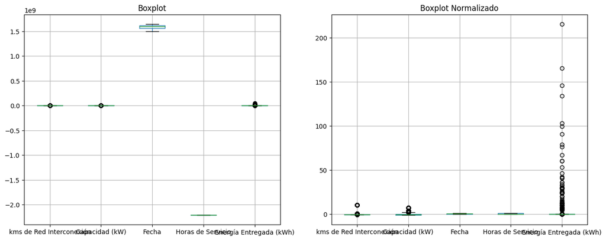

```python
plot_boxplots(df,df_normalized)
```

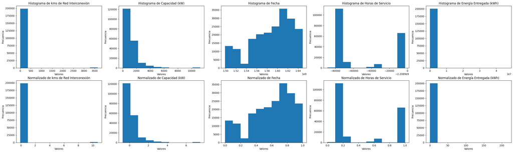

```python
plot_histograms([df,df_normalized])
```

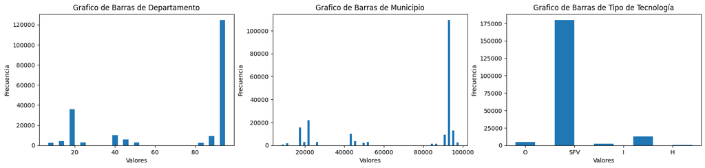

```python
plot_bar_charts(df)
```

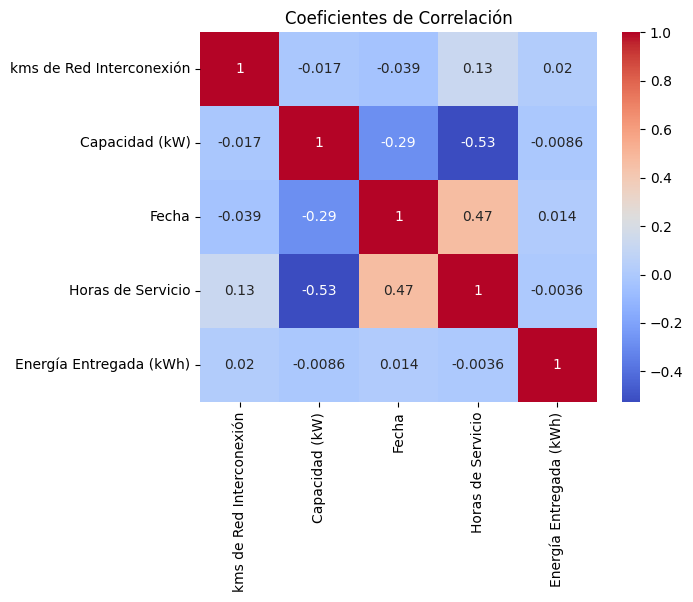

```python
plot_correlation_matrix(df)
```

**Observaciones**